# Final Report for IMDb Movie Bias

Marie Hasegawa - `mhasegawa7045@floridapoly.edu`

[figure not shown]

## Section 1: Introduction

The box office industry is one of the largest global markets in the entertainment industry. According to **IMDbPro**,the industry has an `annual average box office revenue` of around *11 to 14 million dollars* and a `yearly total gross` of around *9 to 12 billion dollars*.

The purpose of the project is to answer two questions:

- How does `Ratings`, `Directors`, `Actors`, `Genres`, `Metascores`, `Runtimes`, and `Revenue` affect the success of a movie and create bias reviews?
- Does `Ratings` correlate with `Metascores`, or do they conflict with each other?

This project will be using the **IMDB_movies.csv** dataset, which is available in the link, IMDB_movies.csv and in `Section 2: Data Analysis`.

### Section 1.1: Index

- Section 1: Introduction
  - Section 1.1: Index
- Section 2: Data Analysis
  - Section 2.1: Genre’s Average rating
  - Section 2.2: Director’s Effect on Rating
  - Section 2.3: Ratings Vs Metascores
  - Section 2.4: Runtime’s Effect on Rating and Metascore
  - Section 2.5: Rating’s and Metascore’s Effect on Revenue
- Section 3: Conclusion

## Section 2: Data Analysis

```r
library(tidyverse)
library(lubridate)
IMDB <- read_csv("https://raw.githubusercontent.com/reisanar/datasets/master/IMDB_movies.csv")
IMDB
```

| Rank | Title | Genre | Description | Director | Actors | Year | Runtime (Minutes) | Rating | Votes | Revenue (Millions) | Metascore |
| --- | --- | --- | --- | --- | --- | --- | --- | --- | --- | --- | --- |
| 1 | Guardians of the Galaxy | Action,Adventure,Sci-Fi | A group of intergalactic criminals are forced to work together to stop a fanatical warrior from taking control of the universe. | James Gunn | Chris Pratt, Vin Diesel, Bradley Cooper, Zoe Saldana | 2014 | 121 | 8.1 | 757074 | 333.13 | 76 |
| 2 | Prometheus | Adventure,Mystery,Sci-Fi | Following clues to the origin of mankind, a team finds a structure on a distant moon, but they soon realize they are not alone. | Ridley Scott | Noomi Rapace, Logan Marshall-Green, Michael Fassbender, Charlize Theron | 2012 | 124 | 7.0 | 485820 | 126.46 | 65 |
| 3 | Split | Horror,Thriller | Three girls are kidnapped by a man with a diagnosed 23 distinct personalities. They must try to escape before the apparent emergence of a frightful new 24th. | M. Night Shyamalan | James McAvoy, Anya Taylor-Joy, Haley Lu Richardson, Jessica Sula | 2016 | 117 | 7.3 | 157606 | 138.12 | 62 |
| 4 | Sing | Animation,Comedy,Family | In a city of humanoid animals, a hustling theater impresario's attempt to save his theater with a singing competition becomes grander than he anticipates even as its finalists' find that their lives w… | Christophe Lourdelet | Matthew McConaughey,Reese Witherspoon, Seth MacFarlane, Scarlett Johansson | 2016 | 108 | 7.2 | 60545 | 270.32 | 59 |
| 5 | Suicide Squad | Action,Adventure,Fantasy | A secret government agency recruits some of the most dangerous incarcerated super-villains to form a defensive task force. Their first mission: save the world from the apocalypse. | David Ayer | Will Smith, Jared Leto, Margot Robbie, Viola Davis | 2016 | 123 | 6.2 | 393727 | 325.02 | 40 |
| 6 | The Great Wall | Action,Adventure,Fantasy | European mercenaries searching for black powder become embroiled in the defense of the Great Wall of China against a horde of monstrous creatures. | Yimou Zhang | Matt Damon, Tian Jing, Willem Dafoe, Andy Lau | 2016 | 103 | 6.1 | 56036 | 45.13 | 42 |
| 7 | La La Land | Comedy,Drama,Music | A jazz pianist falls for an aspiring actress in Los Angeles. | Damien Chazelle | Ryan Gosling, Emma Stone, Rosemarie DeWitt, J.K. Simmons | 2016 | 128 | 8.3 | 258682 | 151.06 | 93 |
| 8 | Mindhorn | Comedy | A has-been actor best known for playing the title character in the 1980s detective series "Mindhorn" must work with the police when a serial killer says that he will only speak with Detective Mindhorn… | Sean Foley | Essie Davis, Andrea Riseborough, Julian Barratt,Kenneth Branagh | 2016 | 89 | 6.4 | 2490 | NA | 71 |
| 9 | The Lost City of Z | Action,Adventure,Biography | A true-life drama, centering on British explorer Col. Percival Fawcett, who disappeared while searching for a mysterious city in the Amazon in the 1920s. | James Gray | Charlie Hunnam, Robert Pattinson, Sienna Miller, Tom Holland | 2016 | 141 | 7.1 | 7188 | 8.01 | 78 |
| 10 | Passengers | Adventure,Drama,Romance | A spacecraft traveling to a distant colony planet and transporting thousands of people has a malfunction in its sleep chambers. As a result, two passengers are awakened 90 years early. | Morten Tyldum | Jennifer Lawrence, Chris Pratt, Michael Sheen,Laurence Fishburne | 2016 | 116 | 7.0 | 192177 | 100.01 | 41 |

[output cut: 990 more lines]

The dataset, *IMDB_movies.csv*, is a collection of the most popular movies rated on IMDb for the past decade. The data fields included are `Rank`, `Title`, `Genre`, `Description`, `Director`, `Actors`, `Year`, `Runtime (Minutes)`, `Rating`, `Votes`, `Revenue (Millions)`, and `Metascore`. **IMDB_movies.csv** was provided by *Professor Rei Sanchez-Arias* under his GitHub account, *reisanar*. The dataset only contains 1000 movies (rows) from 2006 to 2016, so movies past 2006 and from the 20th century will take no part in this analysis.

This section will have 5 subsections: *Genre’s Average rating, Director’s Effect on Rating and Metascore, Ratings Vs Metascores, Runtime’s Effect on Rating and Metascore, and Rating’s and Metascore’s Effect on Revenue*. Each sub-section will illustrate how `Genre`, `Director`, `Revenue`, `Metascore`, `Runtime`, and `Revenue` affects a movie’s box office success and creates bias reviews.

### Section 2.1: Genre’s Average Rating

```r
# Average Rating of Action Movies
Action<-IMDB %>%
  filter(grepl('Action', Genre))
summarize(Action,avgRat_Action=mean(Rating, na.rm = TRUE))

# Average Rating of Sci-Fi Movies
Sci_Fi<-IMDB %>%
  filter(grepl('Sci-Fi', Genre))
summarize(Sci_Fi,avgRat_SciFi=mean(Rating, na.rm = TRUE))

# Average Rating of Drama Movies
Drama<-IMDB %>%
  filter(grepl('Drama', Genre))
summarize(Drama,avgRat_Drama=mean(Rating, na.rm = TRUE))

# Average Rating of Thriller Movies
Thriller<-IMDB %>%
  filter(grepl('Thriller', Genre))
summarize(Thriller,avgRat_Thriller=mean(Rating, na.rm = TRUE))

# Average Rating of Mystery Movies
Mystery<-IMDB %>%
  filter(grepl('Mystery', Genre))
summarize(Mystery,avgRat_Mystery=mean(Rating, na.rm = TRUE))

# Average Rating of Romance Movies
Romance<-IMDB %>%
  filter(grepl('Romance', Genre))
summarize(Romance,avgRat_Rom=mean(Rating, na.rm = TRUE))

# Average Rating of Biography Movies
Bio<-IMDB %>%
  filter(grepl('Biography', Genre))
summarize(Bio,avgRat_Bio=mean(Rating, na.rm = TRUE))

# Average Rating of Music Movies
Music<-IMDB %>%
  filter(grepl('Music', Genre))
summarize(Music,avgRat_Music=mean(Rating, na.rm = TRUE))

# Average Rating of Horror Movies
Horror<-IMDB %>%
  filter(grepl('Horror', Genre))
summarize(Horror,avgRat_Horror=mean(Rating, na.rm = TRUE))

# Average Rating of Adventure Movies
Adventure<-IMDB %>%
  filter(grepl('Adventure', Genre))
summarize(Adventure,avgRat_Adventure=mean(Rating, na.rm = TRUE))


# Average Rating of Fantasy Movies
Fantasy<-IMDB %>%
  filter(grepl('Fantasy', Genre))
summarize(Fantasy,avgRat_Fantasy=mean(Rating, na.rm = TRUE))


# Average Rating of History Movies
History<-IMDB %>%
  filter(grepl('History', Genre))
summarize(History,avgRat_History=mean(Rating, na.rm = TRUE))

# Average Rating of Animation Movies
Animation<-IMDB %>%
  filter(grepl('Animation', Genre))
summarize(Animation,avgRat_Animation=mean(Rating, na.rm = TRUE))

# Average Rating of Comedy Movies
Comedy<-IMDB %>%
  filter(grepl('Comedy', Genre))
summarize(Comedy,avgRat_Comedy=mean(Rating, na.rm = TRUE))

# Average Rating of Crime Movies
Crime<-IMDB %>%
  filter(grepl('Crime', Genre))
summarize(Crime,avgRat_Crime=mean(Rating, na.rm = TRUE))
```

```r
# Data frame of Genres Average Rating
Genre<-c("Action", "SciFi", "Drama", "Thriller", "Mystery", "Romance", "Biography", "Music", "Horror", "Adventure", "Fantasy", "History", "Animation", "Comedy", "Crime")
Average_Rate_Genre<-c(6.614521, 6.716667, 6.953801, 6.593333, 6.886792, 6.685816, 7.290123, 7.042857, 6.089916, 6.772201, 6.548515, 7.127586, 7.32449, 6.64767, 6.786667)
```

```r
# Data frame of Genres Average Rating arranged Descending Average Rating Grouped by Genre
Genre_Average_Rating<-data.frame(Genre, Average_Rate_Genre)
Genre_Rating_Order<-Genre_Average_Rating %>%
  arrange(desc(Average_Rate_Genre))
Genre_Rating_Order
```

| Genre | Average_Rate_Genre |
| --- | --- |
| Animation | 7.324490 |
| Biography | 7.290123 |
| History | 7.127586 |
| Music | 7.042857 |
| Drama | 6.953801 |
| Mystery | 6.886792 |
| Crime | 6.786667 |
| Adventure | 6.772201 |
| SciFi | 6.716667 |
| Romance | 6.685816 |

[output cut: 5 more lines]

*The data frame above shows the average rating based on genre and is arranged by average rating in descending order.*

### Section 2.2: Director’s Effect on Rating

```r
# Version 1
# IMDB_with_Dir_tally <- IMDB %>%
#       arrange(desc(Rating)) %>%
#       select(Title, Director, Actors, Rating, Metascore) %>%
#       group_by(Director) %>%
#       mutate(count_mov = n())
# IMDB_with_Dir_tally

# Data Frame that lists Directors by Descending Number of Movies
num_movies_by_director<-tally(group_by(IMDB,Director), sort=TRUE) %>%
  head(n=10)
num_movies_by_director
```

| Director | n |
| --- | --- |
| Ridley Scott | 8 |
| David Yates | 6 |
| M. Night Shyamalan | 6 |
| Michael Bay | 6 |
| Paul W.S. Anderson | 6 |
| Antoine Fuqua | 5 |
| Christopher Nolan | 5 |
| Danny Boyle | 5 |
| David Fincher | 5 |
| Denis Villeneuve | 5 |

```r
# Data Frame that lists Directors by Descending Average Rating
avg_rating_Dir_table<- IMDB %>%
  group_by(Director) %>%
  summarize(avg_rating=mean(Rating, na.rm=TRUE)) %>%
  arrange(desc(avg_rating)) %>%
  head(n=10)
avg_rating_Dir_table
```

| Director | avg_rating |
| --- | --- |
| Nitesh Tiwari | 8.80 |
| Christopher Nolan | 8.68 |
| Makoto Shinkai | 8.60 |
| Olivier Nakache | 8.60 |
| Aamir Khan | 8.50 |
| Florian Henckel von Donnersmarck | 8.50 |
| Damien Chazelle | 8.40 |
| Naoko Yamada | 8.40 |
| Amber Tamblyn | 8.30 |
| Lee Unkrich | 8.30 |

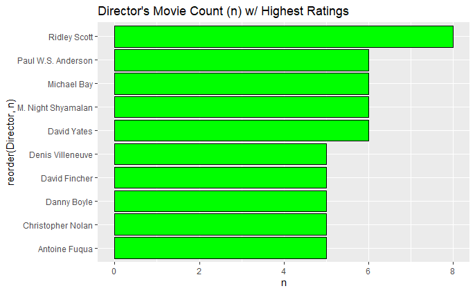

```r
# Director's Movie Count (n) w/ Highest Ratings Bar Chart
ggplot(data = num_movies_by_director, mapping = aes(x = reorder(Director, n), n)) +
  ggtitle("Director's Movie Count (n) w/ Highest Ratings") +
  geom_bar(stat = "identity", color="black", fill="green") + coord_flip()
```

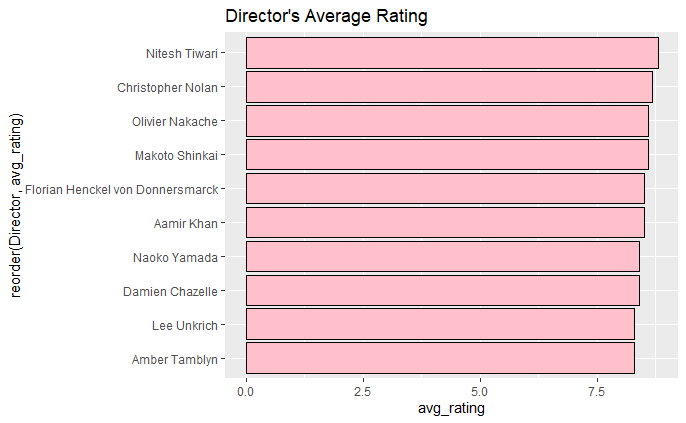

```r
# Director's Average Rating Bar Chart
ggplot(data = avg_rating_Dir_table, mapping = aes(x = reorder(Director, avg_rating), avg_rating)) +
    ggtitle("Director's Average Rating") +
  geom_bar(stat = "identity", color="black", fill="pink") + coord_flip()
```

However, one of the movies (*The Dark Knight Rises*) is a sequel of the other and is based on a very popular *Marvel* icon, *Batman*, which could have compromised the legitimacy of the `Ratings`.

```r
# Data Frame that lists Christopher Nolan's Movies by Descending Rating
Christopher_Nolan<-IMDB %>%
  arrange(desc(Rating)) %>%
  select(Title, Genre, Director, Actors, Rating, Metascore) %>%
  filter(Director == 'Christopher Nolan')
Christopher_Nolan
```

| Title | Genre | Director | Actors | Rating | Metascore |
| --- | --- | --- | --- | --- | --- |
| The Dark Knight | Action,Crime,Drama | Christopher Nolan | Christian Bale, Heath Ledger, Aaron Eckhart,Michael Caine | 9.0 | 82 |
| Inception | Action,Adventure,Sci-Fi | Christopher Nolan | Leonardo DiCaprio, Joseph Gordon-Levitt, Ellen Page, Ken Watanabe | 8.8 | 74 |
| Interstellar | Adventure,Drama,Sci-Fi | Christopher Nolan | Matthew McConaughey, Anne Hathaway, Jessica Chastain, Mackenzie Foy | 8.6 | 74 |
| The Prestige | Drama,Mystery,Sci-Fi | Christopher Nolan | Christian Bale, Hugh Jackman, Scarlett Johansson, Michael Caine | 8.5 | 66 |
| The Dark Knight Rises | Action,Thriller | Christopher Nolan | Christian Bale, Tom Hardy, Anne Hathaway,Gary Oldman | 8.5 | 78 |

Choice of `Genre` could have played a role in *Nolan’s* success, since his movies are categorized with one of the most popular movie `Genres`:

- *Drama* has the **5th** highest Rating based on `Genre` (**6.953801** )
- *Mystery* has the **6th** highest `Rating` based on `Genre` (**6.886792**)
- *Crime* has the **7th** highest `Rating` based on `Genre` (**6.786667**)
- *Adventure* has the **8th** highest `Rating` based on `Genre` (**6.772201**)
- *SciFi* has the **9th** highest `Rating` based on `Genre` (**6.716667**)
- *Action* has the **12th** highest `Rating` based on `Genre` (**6.614521**)
- *Thriller* has the **13th** highest `Rating` based on `Genre` (**6.593333**)

```r
Genre_Rating_Order %>%
  filter(Genre == "Drama" | Genre =="Mystery" | Genre =="Crime" | Genre =="Adventure" | Genre =="SciFi" | Genre =="Action" | Genre =="Thriller")
```

| Genre | Average_Rate_Genre |
| --- | --- |
| Drama | 6.953801 |
| Mystery | 6.886792 |
| Crime | 6.786667 |
| Adventure | 6.772201 |
| SciFi | 6.716667 |
| Action | 6.614521 |
| Thriller | 6.593333 |

Christian Bale has an average movie `Rating` of *7.246154*. This actor has played in 3 major roles of Nolan’s movies—**The Dark Knight, The Prestige, and The Dark Knight Rises**. These 3 movies have been successful due to *Christian Bale’s* contribution as an actor.

```r
# Average Rating of Christian Bale
Christian_Bale<-IMDB %>%
  filter(grepl('Christian Bale', Actors))
summarize(Christian_Bale,avgRat_Christ_Bale=mean(Rating, na.rm = TRUE))
```

| avgRat_Christ_Bale |
| --- |
| 7.246154 |

```r
NA
```

### Section 2.3: Ratings Vs Metascores

`Ratings` and `Metascore` are not exclusively equivalent, since `Ratings` are made by ordinary people while `Metascores` are made by licensed critics. This idea will be explored with two dataframes—**RateVsMeta**, which is arranged in descending `Rating`, and **MetaVsRate**, which is arranged in descending `Metascore`. Let this project assume that a `Rating` of 10 is equivalent to a `Metascore` of 100.

```r
# Data Frame arranged by Descending Rating with Average Rating and Average Metascore
RateVsMeta<-IMDB %>%
  select(Title, Rating, Metascore) %>%
  mutate(avg_rates=mean(Rating), avg_meta=mean(Metascore, na.rm=TRUE)) %>%
  arrange(desc(Rating))
RateVsMeta
```

| Title | Rating | Metascore | avg_rates | avg_meta |
| --- | --- | --- | --- | --- |
| The Dark Knight | 9.0 | 82 | 6.7232 | 58.98504 |
| Inception | 8.8 | 74 | 6.7232 | 58.98504 |
| Dangal | 8.8 | NA | 6.7232 | 58.98504 |
| Interstellar | 8.6 | 74 | 6.7232 | 58.98504 |
| Kimi no na wa | 8.6 | 79 | 6.7232 | 58.98504 |
| The Intouchables | 8.6 | 57 | 6.7232 | 58.98504 |
| The Prestige | 8.5 | 66 | 6.7232 | 58.98504 |
| The Departed | 8.5 | 85 | 6.7232 | 58.98504 |
| The Dark Knight Rises | 8.5 | 78 | 6.7232 | 58.98504 |
| Whiplash | 8.5 | 88 | 6.7232 | 58.98504 |

[output cut: 990 more lines]

```r
# Data Frame arranged by Metascore with Average Rating and Average Metascore
MetaVsRate<- IMDB %>%
  select(Title, Metascore, Rating) %>%
  mutate(avg_meta=mean(Metascore, na.rm=TRUE), avg_rates=mean(Rating)) %>%
  arrange(desc(Metascore))
MetaVsRate
```

| Title | Metascore | Rating | avg_meta | avg_rates |
| --- | --- | --- | --- | --- |
| Boyhood | 100 | 7.9 | 58.98504 | 6.7232 |
| Moonlight | 99 | 7.5 | 58.98504 | 6.7232 |
| Pan's Labyrinth | 98 | 8.2 | 58.98504 | 6.7232 |
| Manchester by the Sea | 96 | 7.9 | 58.98504 | 6.7232 |
| 12 Years a Slave | 96 | 8.1 | 58.98504 | 6.7232 |
| Ratatouille | 96 | 8.0 | 58.98504 | 6.7232 |
| Gravity | 96 | 7.8 | 58.98504 | 6.7232 |
| The Social Network | 95 | 7.7 | 58.98504 | 6.7232 |
| Zero Dark Thirty | 95 | 7.4 | 58.98504 | 6.7232 |
| Carol | 95 | 7.2 | 58.98504 | 6.7232 |

[output cut: 990 more lines]

These observations prove that people and critics have different criteria for ranking a movie’s quality, which can be further proven in the scatter plot, **Rating Vs Metascore Scatter Plot**. The scatter plot shows that many highly rated movies fall under the `Metascore` coordinate of the regression line, but movies that performed very well in the `Metascore` rarely fall behind the `Ratings` on the line, which is illustrated in the scatter plot, **Metascore Vs Rating Scatter Plot**.

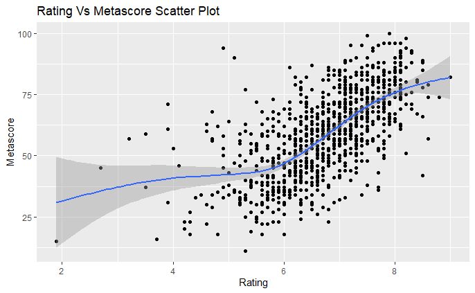

```r
# Scatter Plot illustrating x = Ratings Vs y = Metascores
ggplot(data = RateVsMeta, aes(x = Rating, y = `Metascore`)) +
  geom_point() +
  geom_smooth() +
  ggtitle("Rating Vs Metascore Scatter Plot")
```

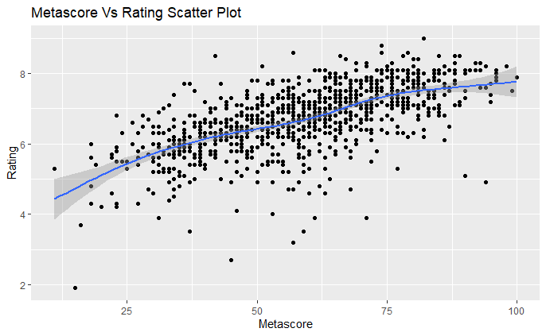

```r
# Scatter Plot illustrating x = Metascore Vs y = Rating
ggplot(data = RateVsMeta, aes(x = Metascore, y = `Rating`)) +
  geom_point() +
  geom_smooth() +
  ggtitle("Metascore Vs Rating Scatter Plot")
```

The highest `Ratings` are more likely to have conflicting `Metascores`, since the points fall farther away from the regression line in the `Rating` coordinates of the scatter plot, **Rating Vs Metascore Scatter Plot**. The highest `Metascores` are less likely to have conflicting `Ratings`, since the points fall closer towards the regression line in the `Metascore` coordinates of the scatter plot, **Metascore Vs Rating Scatter Plot**.

### Section 2.4: Runtime’s Effect on Rating and Metascore

A movie’s `Rating` and `Metascore` can be affected by the length of a movie i.e. a movie’s `Runtime`. A longer `Runtime` allows a movie to explore its story more organically and are less likely to cut corners in order to fit a limited `Runtime`. Yet, an extended `Runtime` can make a movie’s storyline lengthy and overdrawn, which can bring lower `Ratings` and `Metascores`. This idea will be explored with the dataframe called **RuntimeVsRateVsMeta** and two scatter plots—**Runtime Vs Rating Scatterplot** and **Runtime Vs Metascore Scatterplot**.

```r
# Data Frame arranged by Descending Runtime with Rating and Metascore
RuntimeVsRateVsMeta<-IMDB %>%
  select(Title, `Runtime (Minutes)`, Rating, Metascore) %>%
  arrange(desc(`Runtime (Minutes)`))
RuntimeVsRateVsMeta
```

| Title | Runtime (Minutes) | Rating | Metascore |
| --- | --- | --- | --- |
| Grindhouse | 191 | 7.6 | NA |
| The Hateful Eight | 187 | 7.8 | 68 |
| The Wolf of Wall Street | 180 | 8.2 | 75 |
| La vie d'Adèle | 180 | 7.8 | 88 |
| Inland Empire | 180 | 7.0 | NA |
| Cloud Atlas | 172 | 7.5 | 55 |
| 3 Idiots | 170 | 8.4 | 67 |
| Interstellar | 169 | 8.6 | 74 |
| Pirates of the Caribbean: At World's End | 169 | 7.1 | 50 |
| The Hobbit: An Unexpected Journey | 169 | 7.9 | 58 |

[output cut: 990 more lines]

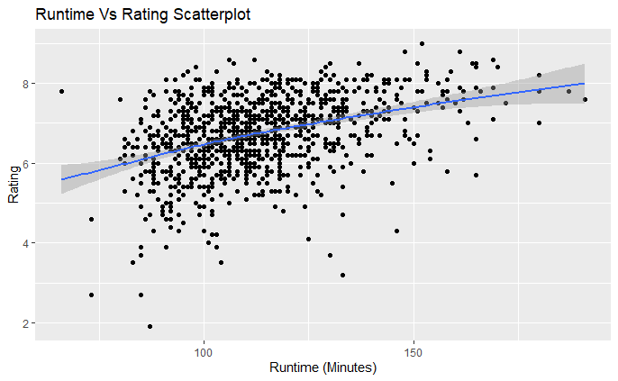

```r
# Scatter Plot illustrating how Runtime affects Ratings
ggplot(data = RuntimeVsRateVsMeta, aes(x = `Runtime (Minutes)`, y = Rating)) +
  ggtitle("Runtime Vs Rating Scatterplot") +
  geom_point() +
  geom_smooth()
```

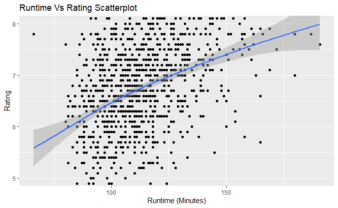

```r
#Close-up
ggplot(data = RuntimeVsRateVsMeta, aes(x = `Runtime (Minutes)`, y = Rating)) +
  ggtitle("Runtime Vs Rating Scatterplot") +
  geom_point() +
  geom_smooth() +
  coord_cartesian(ylim = c(5, 8))
```

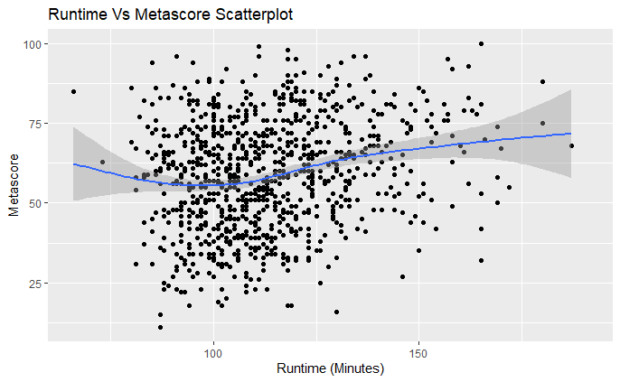

```r
# Scatter Plot illustrating how Runtime affects Metascores
ggplot(data = RuntimeVsRateVsMeta, aes(x = `Runtime (Minutes)`, y = Metascore)) +
  geom_point() +
  ggtitle("Runtime Vs Metascore Scatterplot") +
  geom_smooth()
```

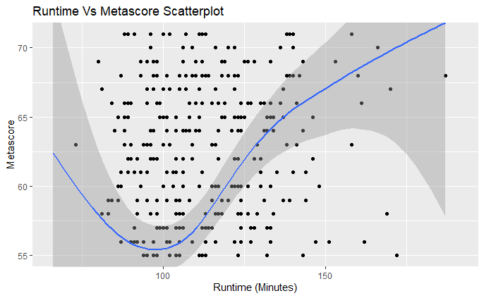

```r
#Close-up
ggplot(data = RuntimeVsRateVsMeta, aes(x = `Runtime (Minutes)`, y = Metascore)) +
  geom_point() +
  ggtitle("Runtime Vs Metascore Scatterplot") +
  geom_smooth() +
  coord_cartesian(ylim = c(55, 71))
```

Based on the 2 scatter plots, the regression line for the scatter plot, **Runtime Vs Rating Scatterplot**, is more linear than the regression line of the other scatter plot, **Runtime Vs Metascore Scatterplot**. This shows that movies’ `Ratings` increase steadily as a movie’s `Runtime` increases. `Metascores` increase in scores as a movies’ `Runtime` increases, but movies with a `Runtime` of around **100 minutes** are more prone to score poorly than any other `Runtime` duration.

Critics prefer a `Runtime` duration of more than **150 minutes** and see it as a more fitting duration that doesn’t disturb the quality of a movie. However, critics view movies with a `Runtime` of around **100 minutes** as a hindrance to the movie’s quality, while normal reviewers believe that a longer `Runtime` duration increases the quality of a movie.

### Section 2.5: Rating’s and Metascore’s Effect on Revenue

Usually in the first week of a movie’s premiere, `Ratings` and `Metascores` are given by first-time viewers who want to give their opinion of the quality of the movie. Besides the advertisements and who the `Actors` and the `Directors` are, `Ratings` and `Metscores` can greatly affect how much viewership and `Revenue` a movie gains in the box office, since positive reviews encourage people to buy tickets while negative reviews causes people to steer clear from the movie theaters.

```r
# Data Frame arranged by Descending Revenue with Rating and Metascore
RateVsMetaVsRevenue<-IMDB %>%
  select(Title, `Revenue (Millions)`, Rating, Metascore) %>%
  arrange(desc(`Revenue (Millions)`))
RateVsMetaVsRevenue
```

| Title | Revenue (Millions) | Rating | Metascore |
| --- | --- | --- | --- |
| Star Wars: Episode VII - The Force Awakens | 936.63 | 8.1 | 81 |
| Avatar | 760.51 | 7.8 | 83 |
| Jurassic World | 652.18 | 7.0 | 59 |
| The Avengers | 623.28 | 8.1 | 69 |
| The Dark Knight | 533.32 | 9.0 | 82 |
| Rogue One | 532.17 | 7.9 | 65 |
| Finding Dory | 486.29 | 7.4 | 77 |
| Avengers: Age of Ultron | 458.99 | 7.4 | 66 |
| The Dark Knight Rises | 448.13 | 8.5 | 78 |
| The Hunger Games: Catching Fire | 424.65 | 7.6 | 76 |

[output cut: 990 more lines]

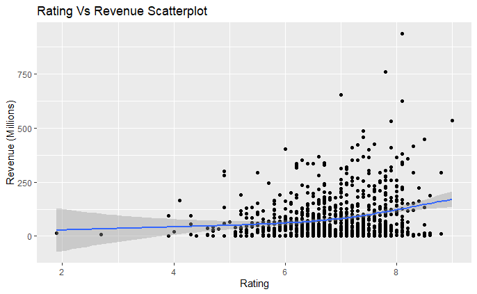

```r
# Scatter Plot illustrating how Ratings affects Revenue
ggplot(data = RateVsMetaVsRevenue, aes(x = Rating, y = `Revenue (Millions)`)) +
  ggtitle("Rating Vs Revenue Scatterplot") +
  geom_point() +
  geom_smooth()
```

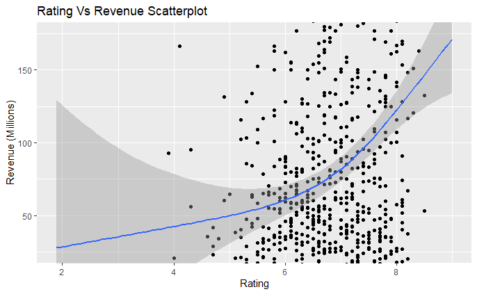

```r
# Close-up
ggplot(data = RateVsMetaVsRevenue, aes(x = Rating, y = `Revenue (Millions)`)) +
  ggtitle("Rating Vs Revenue Scatterplot") +
  geom_point() +
  geom_smooth() +
  coord_cartesian(ylim = c(25, 175))
```

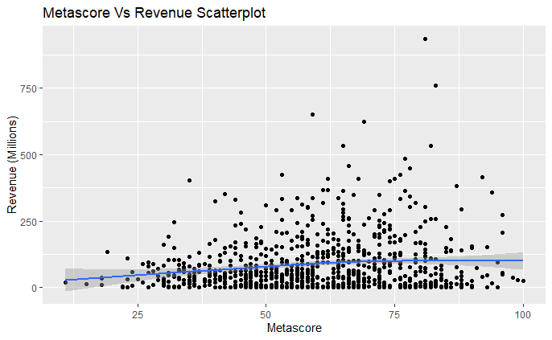

```r
# Scatter Plot illustrating how Metascores affects Revenue
ggplot(data = RateVsMetaVsRevenue, aes(x = Metascore, y = `Revenue (Millions)`)) +
  ggtitle("Metascore Vs Revenue Scatterplot") +
  geom_point() +
  geom_smooth()
```

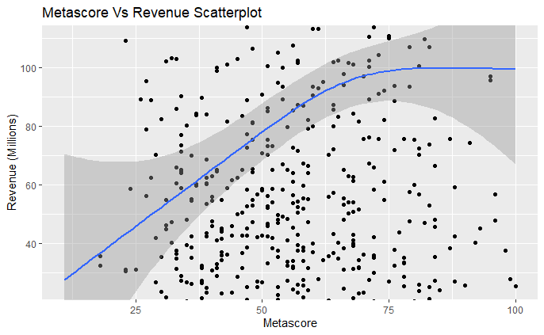

```r
# Close-up
ggplot(data = RateVsMetaVsRevenue, aes(x = Metascore, y = `Revenue (Millions)`)) +
  ggtitle("Metascore Vs Revenue Scatterplot") +
  geom_point() +
  geom_smooth()  +
  coord_cartesian(ylim = c(25, 110))
```

In the scatter plots, **Rating Vs Revenue Scatterplot**, `Revenue` exponentially grows as its `Ratings` increases. However, in the scatter plot **Metascore Vs Revenue Scatterplot**, `Revenue` has a logistic growth as `Metascore` increases. `Revenue` reaches a `Revenue` plateau of around *$100 million* with a `Metascore` range *from 70 to 100*.

Therefore, higher `Ratings` (in an exponential sense) and higher `Metascores` (in a logistic sense), will lead to higher `Revenue` and viewership in the box office.

## Section 3: Conclusion

The Box office industry is one of the highest-grossing media franchises that can accumulate a yearly average `box office revenue` of around *11 to 14 million dollars* and a yearly `total gross` of around *9 to 12 billion dollars*. Many movies’ box office success are affected by `Rating`, `Director`, `Actors`, `Genre`, `Metascore`, `Runtime`, and `Revenue`.

Directors can earn top `Ratings` if they pick the right `Actors` and the most popular `Genres`. Not to mention, `Directors` can ride on previous success by making high-quality sequels.

`Ratings` and `Metascores` can greatly conflict with each other. The highest `Ratings` are more prone to conflict with its `Metascores`, but the highest `Metascores` is less likely to conflict with its `Ratings`.

The length of a movie i.e. a movie’s `Runtime` can affect the `Rating` and `Metascore` of the movie. Normal reviewers’ `Ratings` steadily increases as the `Runtime` increases, while critics highly prefer a `Runtime` of **150 minutes** over a `Runtime` of **100 minutes**.

During the first week of a movie’s premiere, `Ratings` and `Metascores` are distributed and can greatly affect the box office success and `Revenue` of a movie. `Ratings` cause an exponential growth for a movie’s `Revenue`, while `Metascores` can cause a logistic growth for a movie’s `Revenue`.

A movie’s `Rating`, `Director`, `Actors`, `Genre`, `Metascore`, `Runtime`, and `Revenue` play a direct role for a movie’s success and can increase positive feedback. However, some of these factors can create biasness that deter the integrity of the `Rating` and `Metascore`.